# Logboek: Publieke Opinie

# Chi-square:

En chi-square test voor alle enquete vragen en de invloed die het geslacht op de keuzes heeft. **Vraag:** Vindt u dat iemand zelf moet kunnen kiezen of die een abortus wil?  
>H0: Het geslacht van het persoon dat de enquete invult heeft geen invloed op hun keuze over het toestaan van de abortus. >H1: Het geslacht van het persoon dat de enquete invult heeft invloed op hun keuze over het toestaan van de abortus.

**23-05-2024:** De H0 en H1 hypotheses worden hier opgesteld voor alle vragen:

**Vraag:** Vindt u dat er voor abortus gekozen mag worden als de gezondheid van de vrouw door de zwangerschap in gevaar kan komen?  
>H0: Het geslacht van het persoon dat de enquete invult heeft geen invloed op hun keuze of een vrouw een abortus mag hebben wanneer haar leven in gevaar is. >H1: Het geslacht van het persoon dat de enquete invult heeft invloed op hun keuze of een vrouw een abortus mag hebben wanneer haar leven in gevaar is.

**Vraag:** Vindt u dat iemand een abortus mag als de zwangerschap een gevolg is van verkrachting?  
>H0: Het geslacht van het persoon dat de enquete invult heeft geen invloed op hun keuze over het toestaan van een abortus wanneer de zwangerschap gevolg is van verkrachting. >H1: Het geslacht van het persoon dat de enquete invult heeft invloed op hun keuze over het toestaan van een abortus wanneer de zwangerschap gevolg is van verkrachting.

**Vraag:** Vindt u dat een minderjarig kind de keuze moet hebben om voor een abortus te kiezen?  
>H0: Het geslacht van het persoon dat de enquete invult heeft geen invloed op hun keuze of een minderjarig kind de keuze moet hebben om voor een abortus te kiezen. >H1: Het geslacht van het persoon dat de enquete invult heeft invloed op hun keuze of een minderjarig kind de keuze moet hebben om voor een abortus te kiezen.

**Vraag:** Vindt u dat de ouders zeggenschap moeten hebben over of hun minderjarige kind wel of niet voor abortus mag kiezen?  
>H0: Het geslacht van het persoon dat de enquete invult heeft geen invloed op hun keuze of de ouders van een minderjarig kind zeggenschap moeten hebben over of hun minderjarige kind wel of niet voor abortus mag kiezen?  
>H1: Het geslacht van het persoon dat de enquete invult heeft invloed op hun keuze of de ouders van een minderjarig kind zeggenschap moeten hebben over of hun minderjarige kind wel of niet voor abortus mag kiezen?

**Vraag:** Moet het wettelijk verplicht worden voor vrouwen die een abortus willen om een echo van de foetus te zien voordat een abortus toegestaan is?  
>H0: Het geslacht van het persoon dat de enquete invult heeft geen invloed op hun keuze of ze vinden dat het wettelijk verplicht worden voor vrouwen die een abortus willen om een echo van de foetus te zien voordat een abortus toegestaan is.  
>H1: Het geslacht van het persoon dat de enquete invult heeft invloed op hun keuze of ze vinden dat het wettelijk verplicht worden voor vrouwen die een abortus willen om een echo van de foetus te zien voordat een abortus toegestaan is.

**Vraag:** Vindt u dat de wettelijke bedenktijd moet terugkomen?  
>H0: Het geslacht van het persoon dat de enquete invult heeft geen invloed op hun keuze of de wettenlijke bedenktijd terug moet komen. >H1: Het geslacht van het persoon dat de enquete invult heeft invloed op hun keuze of de wettenlijke bedenktijd terug moet komen.

**Vraag:** Vindt u dat adoptie een alternatief is voor abortus?  
>H0: Het geslacht van het persoon dat de enquete invult heeft geen invloed op hun keuze of adoptie een alternatief is voor abortus. >H1: Het geslacht van het persoon dat de enquete invult heeft invloed op hun keuze of adoptie een alternatief is voor abortus.

**Vraag:** Moet de biologische vader zeggenschap hebben over de beslissing voor een abortus? >H0: Het geslacht van het persoon dat de enquete invult heeft geen invloed op hun keuze of de biologische vader zeggenschap moet hebben over de beslissing voor een abortus. >H1: Het geslacht van het persoon dat de enquete invult heeft invloed op hun keuze of de biologische vader zeggenschap moet hebben over de beslissing voor een abortus.

```r
#onder21 <- filter(abortus$Wat.is.uw.leeftijd., abortus$Wat.is.uw.leeftijd. < 21)

#binaire_lijst_keuze_abortus <-

#ja_abortus <- (ifelse(abortus$eigen_keuze_abortus=="Wel abortus toestaan", 1,0)) # 1 voor de mensen de voorstander zijn, 0 als ze tegen zijn.
ja_abortus <- table(df$geslacht, df$eigen_keuze_abortus)
chi_ja_abortus <- chisq.test(ja_abortus, correct = T)
ja_abortus_onder_21_df <-  df %>%
  filter(df$Wat.is.uw.leeftijd. <= 21)
ja_abortus_onder_21 <- (ifelse(ja_abortus_onder_21_df$eigen_keuze_abortus=="Wel abortus toestaan", 1,0))
#all(duplicated(abortus$geslacht)[-1L])

#ja_nee_abortus_onder_21 <- chisq.test(df$geslacht, ja_abortus, correct = T)

# boven de 21:
ja_abortus_onder_21_df <-  df %>%
  filter(df$Wat.is.uw.leeftijd. > 21)
ja_abortus_onder_21 <- (ifelse(ja_abortus_onder_21_df$eigen_keuze_abortus=="Wel abortus toestaan", 1,0))
#all(duplicated(abortus$geslacht)[-1L])

#ja_nee_abortus_onder_21 <- chisq.test(df$geslacht, ja_abortus, correct = T)


#ja_nee_abortus <- t.test(ja_abortus, as.numeric(abortus$geslacht), data = abortus, alternative = "two.sided")


# Resultaat kan bijna niet kloppen.... achterhaal wat er mis is.
```

```r
# Chi-square voor de vraag: Vindt u dat iemand een abortus mag als de zwangerschap een gevolg is van verkrachting?

# Lijst van 1 en 0 maken voor Ja en Nee.
#abortus_als_gevolg_van_01 <- (ifelse(abortus$Vindt.u.dat.iemand.een.abortus.mag.als.de.zwangerschap.een.gevolg.is.van.verkrachting.=="Ja", 1,0)) # 1 voor de mensen de voorstander zijn, 0 als ze tegen zijn.

abortus_als_gevolg_van_01 <- table(df$geslacht, df$Vindt.u.dat.iemand.een.abortus.mag.als.de.zwangerschap.een.gevolg.is.van.verkrachting.)

# Chi-square test:
chi_abortus_als_gevolg_van <- chisq.test(abortus_als_gevolg_van_01, correct = T)
# Chi-square voor de vraag: Vindt u dat een minderjarig kind de keuze moet hebben om voor een abortus te kiezen?

# Lijst van 1 en 0 maken voor Ja en Nee.
#abortus_minderjarig_keuze_01 <- (ifelse(abortus$minderjarig=="Ja", 1,0)) # 1 voor de mensen de voorstander zijn, 0 als ze tegen zijn.

abortus_minderjarig_keuze_01 <- table(df$geslacht, df$minderjarig)

# Chi-square test:
chi_abortus_minderjarig_keuze <- chisq.test(abortus_minderjarig_keuze_01, correct = T)
# Chi-square voor de vraag: Vindt u dat de ouders zeggenschap moeten hebben over of hun minderjarige kind wel of niet voor abortus mag kiezen?

# Lijst van 1 en 0 maken voor Ja en Nee.
#abortus_zeggenschap_ouders_01 <- (ifelse(abortus$ouders=="Ja", 1,0)) # 1 voor de mensen de voorstander zijn, 0 als ze tegen zijn.
abortus_zeggenschap_ouders_01 <- table(df$geslacht, df$ouders)
# Chi-square test:
chi_abortus_zeggenschap_ouders <- chisq.test(abortus_zeggenschap_ouders_01, correct = T)
# Test om leeftijd mee te nemen als factor:
#chi_abortus_als_gevolg_van_leeftijd <- chisq.test(df$Wat.is.uw.leeftijd., abortus_zeggenschap_ouders, correct = T)
```

```r
# Chi-square voor de vraag: Moet het wettelijk verplicht worden voor vrouwen die een abortus willen om een echo van de foetus te zien voordat een abortus toegestaan is?

# Lijst van 1 en 0 maken voor Ja en Nee.
#abortus_echo_01 <- (ifelse(abortus$minderjarig=="Ja", 1,0)) # 1 voor de mensen de voorstander zijn, 0 als ze tegen zijn.
abortus_echo_01 <- table(df$geslacht, df$minderjarig)
# Chi-square test:
chi_abortus_echo <- chisq.test(abortus_echo_01, correct = T)
# Chi-square voor de vraag: Vindt u dat de wettelijke bedenktijd moet terugkomen?

# Lijst van 1 en 0 maken voor Ja en Nee.
#abortus_bedenktijd_01 <- (ifelse(abortus$bedenktijd=="Ja", 1,0)) # 1 voor de mensen de voorstander zijn, 0 als ze tegen zijn.
abortus_bedenktijd_01 <- table(df$geslacht, df$bedenktijd)
# Chi-square test:
chi_abortus_bedenktijd <- chisq.test(abortus_bedenktijd_01, correct = T)
# Chi-square voor de vraag: Vindt u dat adoptie een alternatief is voor abortus?

# Lijst van 1 en 0 maken voor Ja en Nee.
#abortus_adoptie_01 <- (ifelse(abortus$adoptie=="Ja", 1,0)) # 1 voor de mensen de voorstander zijn, 0 als ze tegen zijn.
abortus_adoptie_01 <- table(df$geslacht, df$adoptie)
# Chi-square test:
chi_abortus_adoptie <- chisq.test(abortus_adoptie_01, correct = T)
# Chi-square voor de vraag: Moet de biologische vader zeggenschap hebben over de beslissing voor een abortus?

# Lijst van 1 en 0 maken voor Ja en Nee.
#abortus_zeggenschap_vader_01 <- (ifelse(abortus$vader=="Ja", 1,0)) # 1 voor de mensen de voorstander zijn, 0 als ze tegen zijn.
abortus_zeggenschap_vader_01 <- table(df$geslacht, df$vader)
# Chi-square test:
chi_abortus_zeggenschap_vader <- chisq.test(abortus_zeggenschap_vader_01, correct = T)
```

## Visualisatie van de Chi-square resultaten:

25-05-2024: Om een overzicht te geven van alle chi-square resulaten voor alle vragen is er een grafiek van gemaakt. De rode lijn geeft significantie aan, wanneer een waarde onder deze lijn ligt (p < 0.05) is het resulaat statistische significant en wanneer de waarde er boven ligt (p > 0.05) is het resulaat niet statistisch significant. Als het resulaat significant is betekend het voor deze stellingen dat er een verschil is tussen de keuze tussen de twee geslachten.

```r
chi_test_vector_geslacht <- c(chi_ja_abortus[3],chi_abortus_als_gevolg_van[3],chi_abortus_minderjarig_keuze[3],chi_abortus_zeggenschap_ouders[3],chi_abortus_echo[3],chi_abortus_bedenktijd[3],chi_abortus_adoptie[3],chi_abortus_zeggenschap_vader[3])

#df_chi_geslacht_test <- data.frame(c(chi_ja_abortus[3],chi_abortus_als_gevolg_van[3]))

df_chi_geslacht <- (data.frame((chi_test_vector_geslacht)) %>% rename(
  `Abortus toestaan` = p.value,
  `Gevolg van verkrachtign` = p.value.1,
  `Minderjarig kind` = p.value.2,
  `Zeggenschap ouders` = p.value.3,
  `Echo bekijken` = p.value.4,
  `Bedenktijd invoeren` = p.value.5,
  `Adoptie als alternatief` = p.value.6,
  `Zeggenschap vader` = p.value.7
  ))

df_chi_geslacht %>%
  pivot_longer(cols = c(1:8)) -> df_chi_geslacht
```

In het bovenstaande blok met code wordt er een data-frame gemaakt die alle p-waardes bevat van de hypothes die opgesteld zijn. Daarna wordt de data veranderd in “tidy data” (een meting per rij en variablen als colommen).

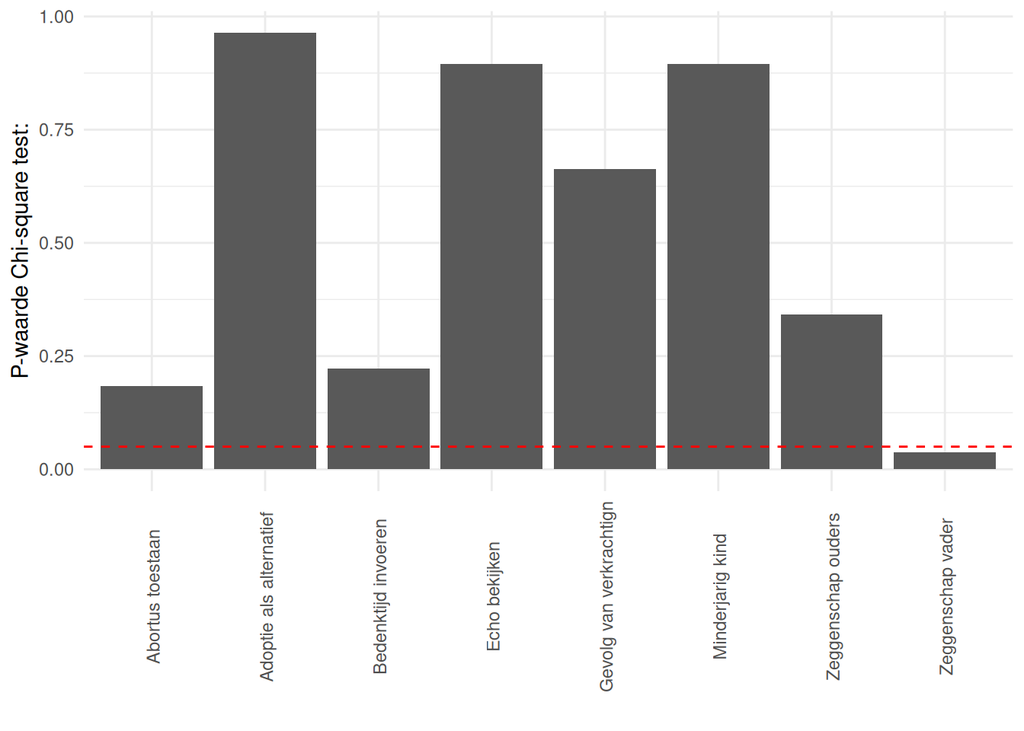

```r
ggplot(data = df_chi_geslacht, mapping = aes(x = name , y = value)) +
  geom_bar(stat = "identity") +
  geom_hline(yintercept=0.05, linetype="dashed", color = "red") +
  ylab("P-waarde Chi-square test:") +
  xlab(" ") +
  theme_minimal() +
  theme(axis.text.x = element_text(angle = 90, vjust = 0.6))
```

Aan de bovenstaande grafiek te zien is er alleen een significant verschil tussen de meningen van de verschillende geslachten voor de kwestie of de vader ook zeggenschap mag hebben over de abortus, dit is van alle vragen de vraag waar ik ook wel van had verwacht dat het een polarizerende vraag zou zijn.

# Chi^2 test:

De volgende hypothese is opgesteld: H0: Geslacht is geen bijdragende factor in de keuze of abortus toegestaan mag zijn of niet. H1: Geslacht is een bijdragende factor in de keuze of abortus toegestaan mag zijn of niet.

```r
# Test om te kijken hoe het werkt:
#test_ja_abortus <- df %>% filter(geslacht == "Man")


#test_ja_abortus <- (ifelse(test_ja_abortus$eigen_keuze_abortus=="Wel abortus toestaan" & #test_ja_abortus$geslacht == "Man", 6,0))
#chisq.test(df$geslacht, ja_abortus ,correct = F)
ja_abortus <- table(df$geslacht, df$eigen_keuze_abortus)
# Chi-square test:
chi_ja_abortus <- chisq.test(ja_abortus, correct = F)
```

De p-waarde van de Chi-square test is: 0.1834973 dit is boven de 0.05 dus kan de nul hypothese aangenomen worden, geslacht is geen significant bijdragende factor in de keuze of abortus toegestaan mag zijn of niet.  
De Chi-squered waarde is: 3.39

```r
# Test met andere variabele

# Lijst van 1 en 0 maken voor Ja en Nee.
abortus_zeggenschap_vader_01 <- (ifelse(abortus$vader=="Ja", 1,0)) # 1 voor de mensen de voorstander zijn, 0 als ze tegen zijn.

# Chi-square test:
chi_abortus_zeggenschap_vader <- chisq.test(df$afkomst, abortus_zeggenschap_vader_01, correct = T)
chi_abortus_zeggenschap_vader
```

```
##
##  Pearson's Chi-squared test
##
## data:  df$afkomst and abortus_zeggenschap_vader_01
## X-squared = 7.447, df = 10, p-value = 0.6827
```

### To-do: voor grafieken proporties gebruiken i.p.v. absolute aantallen (om rekening te houden met verschillen en aantal “metingen” tussen mannen en vrouwen.)

21-05-2024: ** Two-way Z-test:** Voor het beantwoorden van de vraag: Heeft het geslacht invloed op de keuze…. (afhankelijk van de vraag, herhalen voor alle vragen)

```r
library("BSDA")
#df_z_test <-
#z_test_abortus <- z.test(df$geslacht, ja_abortus, sigma.x = sd(df$geslacht))
```

To-do:

### Grafiek leeftijd/keuze:

Op de onderstaande grafiek wordt het verband tussen leeftijd en keuze bij de vraag: wel of niet abortus toestaan weergeven.

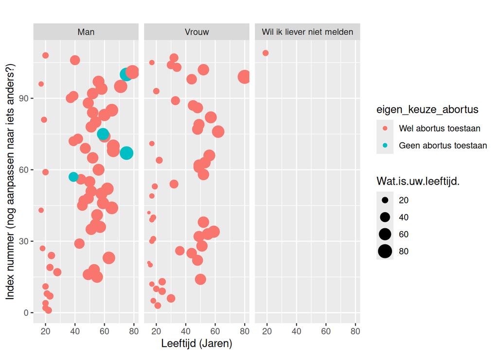

```r
ggplot(data = df, mapping = aes(x = Wat.is.uw.leeftijd., y = c(1:109))) +
  geom_point(aes(color = eigen_keuze_abortus, size = Wat.is.uw.leeftijd.)) +
  facet_wrap(~geslacht) +
  xlab("Leeftijd (Jaren)") +
  ylab("Index nummer (nog aanpassen naar iets anders?)") +
  ggtitle("")
```

**29-05-2024:** Alle chi-square tests retroactief aangepast, nu met een tabel i.p.v. eerst alle waarden van de vragen omzetten in 1 (Eens) en 0 (Oneens).

**30-05-2024:**

# Logistische regressie:

Om het verband tussen meerdere predictors te zien is de logistische regressie gebruikt.

Omdat er niet genoeg mensen van elk geloof zijn wordt iedereen verdeeld in twee groepen, gelovig en niet gelovig, het is natuurlijk genuanceerder dan dat maar met deze versimpeling zal ook al wel een patroon zichtbaar gemaakt kunnen worden.

```r
df <- df %>%
  mutate(gelovig_01 = ifelse(df$geloof == "Niet gelovig", 0,1))
```

### Dataframes maken voor de logistische regressie:

**In de onderstaande code chunks worden er dataframes gemaakt voor de volgende tests:** Keuze van de man met leeftijd en opleidingsniveau als predictors, Keuze van de vrouw met leeftijd en opleidingsniveau als predictors, en Keuze van mensen met ongespecificeerd geslacht met leeftijd en opleidingsniveau als predictors. Van deze laatste categorie is er maar een persoon, dus kan hier de analyze niet op uitevoerd worden.

```r
# Nieuw dataframe met de relevante colommen van df.
#df_logistische_regressie <- data.frame(ID = df$ID, geslacht =df$geslacht, leeftijd = df$Wat.is.uw.leeftijd., keuze = df$eigen_keuze_abortus, df$geloof)

df_logistische_regressie <- df %>%
  select(geslacht, Wat.is.uw.leeftijd., gelovig_01, Wat.is.het.hoogste.onderwijsniveau.dat.u.heeft.afgerond., eigen_keuze_abortus, vader, bedenktijd, minderjarig, gezondheid_vrouw, ouders)
```

```r
# Dataframe voor man:
df_man <- df %>%
  select(geslacht, Wat.is.uw.leeftijd., gelovig_01, Wat.is.het.hoogste.onderwijsniveau.dat.u.heeft.afgerond., eigen_keuze_abortus, vader, bedenktijd, minderjarig, gezondheid_vrouw, ouders) %>%
  filter(geslacht == "Man")
```

```r
# Dataframe voor vrouw:
df_vrouw <- df %>%
  select(geslacht, Wat.is.uw.leeftijd., gelovig_01, Wat.is.het.hoogste.onderwijsniveau.dat.u.heeft.afgerond., eigen_keuze_abortus, vader, bedenktijd, minderjarig, gezondheid_vrouw, ouders) %>% filter(geslacht == "Vrouw")
```

```r
# Dataframe voor ongespecificeerd geslacht:
df_ongespecificeerd_geslacht <- df %>%
  select(geslacht, Wat.is.uw.leeftijd., gelovig_01, Wat.is.het.hoogste.onderwijsniveau.dat.u.heeft.afgerond., eigen_keuze_abortus, vader, bedenktijd, minderjarig, gezondheid_vrouw, ouders) %>% filter(geslacht == "Wil ik liever niet melden ")
```

```r
# logistische_regressie voor de vraag "moet abortus een eigen keuze zijn?" met als voorspellende factoren (predictors) leeftijd, geslacht en opleidingsniveau.
logistische_regressie_test <- glm(df$eigen_keuze_abortus ~ df$Wat.is.uw.leeftijd. + df$geslacht + df$Wat.is.het.hoogste.onderwijsniveau.dat.u.heeft.afgerond., data = df, family = binomial)
```

```
## Warning: glm.fit: fitted probabilities numerically 0 or 1 occurred
```

Voor de logistische_regressie voor de vraag “moet abortus een eigen keuze zijn?” met als predictors leeftijd, geslacht en opleidingsniveau gaf R een waarschuwing: Warning: glm.fit: fitted probabilities numerically 0 or 1 occurred. Mogenlijk komt dit omdat er niet genoeg metingen zijn voor elk opleidingsniveau, daarom is opleidingsniveau weggehaald as predictor in het onderstaande code blok.

```r
# Logistische regressie met leeftijd en geslacht als predictors
logistische_regressie <- glm(eigen_keuze_abortus ~ Wat.is.uw.leeftijd. + geslacht, data = df_logistische_regressie, family = binomial)
logistische_regressie
```

```
##
## Call:  glm(formula = eigen_keuze_abortus ~ Wat.is.uw.leeftijd. + geslacht,
##     family = binomial, data = df_logistische_regressie)
##
## Coefficients:
##                       (Intercept)                Wat.is.uw.leeftijd.
##                           -7.3760                             0.0868
##                     geslachtVrouw  geslachtWil ik liever niet melden
##                          -17.1680                           -14.8394
##
## Degrees of Freedom: 108 Total (i.e. Null);  105 Residual
## Null Deviance:       34.29
## Residual Deviance: 24.7  AIC: 32.7
```

```r
# Logistische regressie voor de vraag: Moet abortus een eigen keuze zijn?
lr_man_eigen_keuze_abortus <- glm(eigen_keuze_abortus ~ Wat.is.uw.leeftijd. + gelovig_01 + Wat.is.het.hoogste.onderwijsniveau.dat.u.heeft.afgerond., data = df_man, family = binomial)
```

```
## Warning: glm.fit: fitted probabilities numerically 0 or 1 occurred
```

```r
#summary(lr_man_eigen_keuze_abortus)
coef(lr_man_eigen_keuze_abortus)
```

```
##                                                               (Intercept)
##                                                              -26.94587603
##                                                       Wat.is.uw.leeftijd.
##                                                                0.07423402
##                                                                gelovig_01
##                                                               21.53120922
##               Wat.is.het.hoogste.onderwijsniveau.dat.u.heeft.afgerond.HBO
##                                                                0.91528824
##               Wat.is.het.hoogste.onderwijsniveau.dat.u.heeft.afgerond.MBO
##                                                                0.87248339
## Wat.is.het.hoogste.onderwijsniveau.dat.u.heeft.afgerond.Middelbare school
##                                                              -18.80687581
##      Wat.is.het.hoogste.onderwijsniveau.dat.u.heeft.afgerond.Universiteit
##                                                              -18.28941081
```

```r
# Logistische regressie voor de vraag: Moet de biologische vader zeggenschap hebben over de abortus
lr_man_vader <- glm(vader ~ Wat.is.uw.leeftijd. + gelovig_01 + Wat.is.het.hoogste.onderwijsniveau.dat.u.heeft.afgerond., data = df_man, family = binomial)
#summary(lr_man_eigen_keuze_abortus)
#summary(lr_man_vader)
```

De odds ratio wordt gebruikt om te laten zien hoeveel invloed de predictors individueel hebben wanneer de anderen niet veranderen.

```r
# Zodat het niet in wetenschappelijke notatie weergeven wordt als het onder de 999 is.
options(scipen = 999)

# Bereken de coefficienten (log e)
coefficienten_van_lr_man_eigen_keuze_abortus <- coef(lr_man_eigen_keuze_abortus)

# Verander de coefficienten naar procentuele verandering:
odds_ratio_lr_man_eigen_keuze_abortus <- ( 1 - (exp(coefficienten_van_lr_man_eigen_keuze_abortus))) * 100
odds_ratio_lr_man_eigen_keuze_abortus
```

```
##                                                               (Intercept)
##                                                                100.000000
##                                                       Wat.is.uw.leeftijd.
##                                                                 -7.705883
##                                                                gelovig_01
##                                                      -224328964378.451538
##               Wat.is.het.hoogste.onderwijsniveau.dat.u.heeft.afgerond.HBO
##                                                               -149.749503
##               Wat.is.het.hoogste.onderwijsniveau.dat.u.heeft.afgerond.MBO
##                                                               -139.284585
## Wat.is.het.hoogste.onderwijsniveau.dat.u.heeft.afgerond.Middelbare school
##                                                                 99.999999
##      Wat.is.het.hoogste.onderwijsniveau.dat.u.heeft.afgerond.Universiteit
##                                                                 99.999999
```

```r
# Voorspel test met de volgende test data:
newdata1 <- data.frame(geslacht = c("Man", "Vrouw"), Wat.is.uw.leeftijd. = c(20,22), keuze = c("Wel abortus toestaan","Wel abortus toestaan"))

# Voorspelling van de bovenstaande twee test observaties aan de hand van de gemaakte logistische regressie:
voorspelde_waarde_1 <- predict.lm(logistische_regressie, newdata = newdata1, type = "response")
voorspelde_waarde_1
```

```
##          1          2
##  -5.639914 -22.634324
```

Met behulp van de predict.lm() functie worden de twee test observaties (net als in de originele dataset) aan de hand van de gemaakte logistische regressie. De nummers moeten nog omgezet worden naar een Ja/Nee antwoord op de vraag: Abortus toestaan. De waarden die verkregen zijn met de predict.lm() functie kunnen vervolgens in de onderstaande grafiek worden geplot om te zien in welke categorie ze waarschijnlijk horen. (Welk antwoord het persoon waarschijnlijk zou geven.)

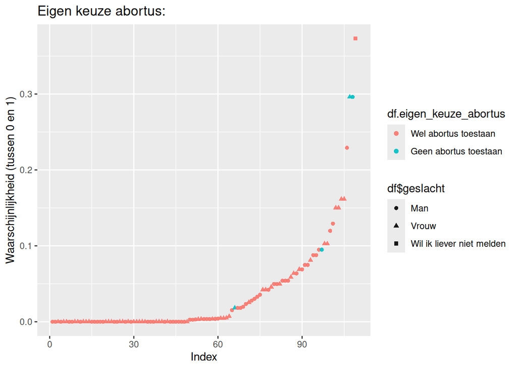

```r
# Maak nieuw dataframe met de waardes van de logistische regressie en de keuze die de mensen die bij deze waardes horen gemaakt hebben.
voorspelde_data <- data.frame(logistische_regressie$fitted.values, df$eigen_keuze_abortus)

voorspelde_data <- voorspelde_data[order(voorspelde_data$logistische_regressie.fitted.values, decreasing = F),]

voorspelde_data$rank <- 1:nrow(voorspelde_data)

ggplot(data = voorspelde_data, aes(x = rank, y = logistische_regressie.fitted.values)) +
  geom_point(aes(color=df.eigen_keuze_abortus, shape = df$geslacht), alpha = 0.9) +
  ggtitle("Eigen keuze abortus:") +
  xlab("Index") +
  ylab("Waarschijnlijkheid (tussen 0 en 1)")
```

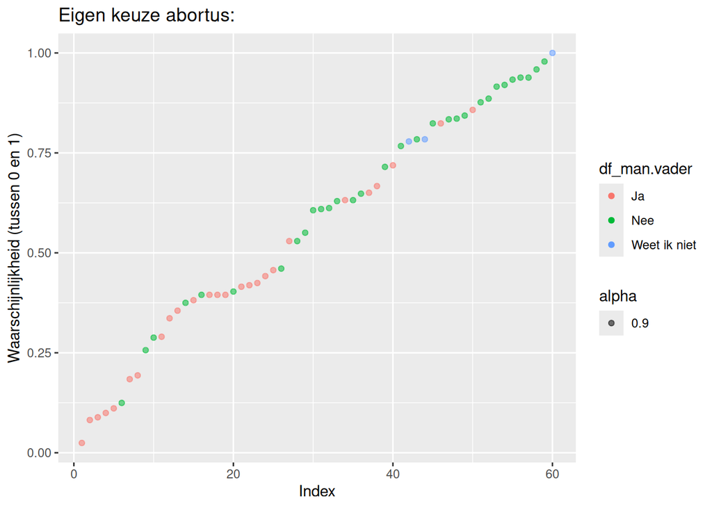

```r
# Maak nieuw dataframe met de waardes van de logistische regressie en de keuze die de mensen die bij deze waardes horen gemaakt hebben.
lr_voorspelling_vader <- data.frame(lr_man_vader$fitted.values, df_man$vader)

lr_voorspelling_vader <- lr_voorspelling_vader[order(lr_voorspelling_vader$lr_man_vader.fitted.values, decreasing = F),]

lr_voorspelling_vader$rank <- 1:nrow(lr_voorspelling_vader)

ggplot(data = lr_voorspelling_vader, aes(x = rank, y = lr_man_vader.fitted.values)) +
  geom_point(aes(color=df_man.vader, alpha = 0.9)) +
  ggtitle("Eigen keuze abortus:") +
  xlab("Index") +
  ylab("Waarschijnlijkheid (tussen 0 en 1)")
```

```r
tabel_geloof_vraag6 <- (table(data_renamed$Abortus_keuze, data_renamed$Religie))
tabel_geloof_vraag6 <- data.frame(tabel_geloof_vraag6)


tabel_geloof_vraag6 <- tabel_geloof_vraag6 %>%
  pivot_wider(names_from = Var2, values_from = Freq)

tabel_geloof_vraag6$totaal_aantal <- (x = tabel_geloof_vraag6$Var1)

(tabel_geloof_vraag6)
```

[output not shown]